# Bhuyan_Chuang_Martinez_CompetitionReport_S25

### Model 4: NNAR + Fourier (K = 3,18)

We tested NNAR + Fourier (K = 3,18) to explore whether adding more seasonal components would improve forecast accuracy. By increasing the number of Fourier terms, the model could capture more detailed seasonal fluctuations and smaller periodic patterns that might not be fully represented with lower K values.

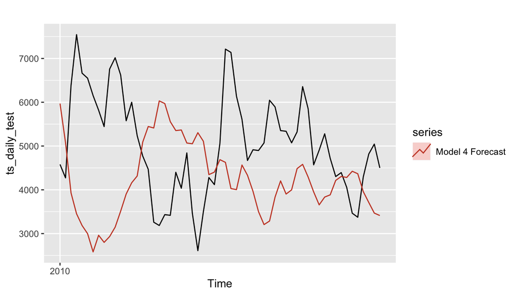

```r
K4 <- c(3,18)
NN_fit_k318 <- nnetar(ts_daily_train, p = 2, P = 2, xreg = fourier(ts_daily_train, K = K4), size = 10, decay = 0.01, maxNWts = 2000)
NN_for_k318 <- forecast(NN_fit_k318, h = horizon, xreg = fourier(ts_daily_train, K = K4, h = horizon))
autoplot(ts_daily_test) + autolayer(NN_for_k318, series = "Model 4 Forecast")
```

```r
accuracy(NN_for_k318, ts_daily_test)
```

```
##                       ME      RMSE       MAE        MPE      MAPE     MASE
## Training set  -0.8735948  207.1179  147.1331 -0.6890271  4.361957 0.191229
## Test set     824.9825802 1962.6246 1641.8153  8.8732819 32.437449 2.133868
##                     ACF1 Theil's U
## Training set -0.07721178        NA
## Test set      0.85015618  2.375306
```

### Model 5: TBATS

We tested TBATS because it is designed to handle seasonal patterns, multiple seasonalities, and nonstationary behavior. In our case, TBATS did not perform as well as the NNAR + Fourier models in the Kaggle competition as load was just better forecasted by a more targeted combination of Fourier-seasonality and a nonlinear neural network, whereas TBATS oversmoothed or lagged behind sharp changes in load.

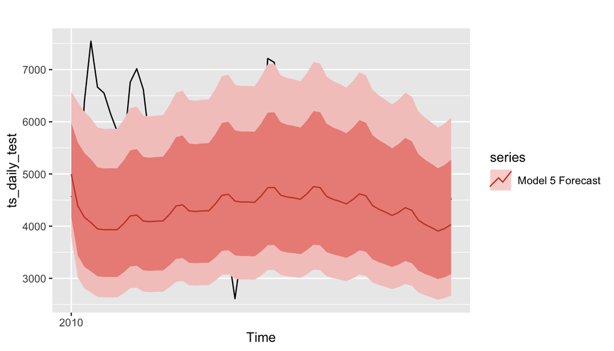

```r
TBATS_fit <- tbats(ts_daily_train)
TBATS_for <- forecast(TBATS_fit, h = horizon)
autoplot(ts_daily_test) + autolayer(TBATS_for, series = "Model 5 Forecast")
```

```r
accuracy(TBATS_for, ts_daily_test)
```

```
##                     ME      RMSE       MAE        MPE     MAPE      MASE
## Training set  43.90081  501.3385  363.7827 -0.6194292 10.78758 0.4728086
## Test set     711.90657 1376.0978 1083.3750  9.2346813 20.45227 1.4080633
##                    ACF1 Theil's U
## Training set 0.03361668        NA
## Test set     0.79537200  1.553679
```